# Metagenomics Summary Report

June 18, 2019

```r
# setup and load necessary libraries
library(knitr)
library(tidyverse)
library(DT)
opts_chunk$set(echo=TRUE, warning=FALSE, message=FALSE)
theme_set(theme_bw())

# Set sample name (parameterized)
id <- params$id
```

Sample ID: **SRR606249_subset10_1_reads**

# About

## Workflow overview

**More info: https://github.com/signaturescience/metagenomics**

These open source metagenomics workflows are intended to analyze the biological contents of complex environmental samples. The expected input is paired-end Illumina FASTQ files, and the current outputs include filtered reads, assembled contigs, MultiQC reports for FastQC and QUAST results, metagenome comparison estimates, taxonomic classifications, and gene predictions.

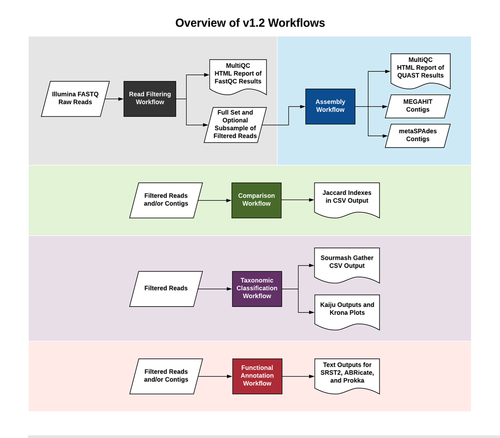

Analysis flowchart

## About this analysis

Analysis completed: **2019-06-06 08:13:59**.

Typical command used to run this analysis:

```bash
snakemake --cores 24 --use-singularity \
    read_filtering_multiqc_workflow \
    read_filtering_khmer_count_unique_kmers_workflow \
    assembly_multiqc_workflow \
    comparison_output_heatmap_plots_all_workflow \
    tax_class_gather_workflow \
    tax_class_visualize_krona_kaijureport_workflow \
    functional_with_srst2_workflow \
    functional_prokka_with_megahit_workflow \
    functional_prokka_with_metaspades_workflow \
    functional_abricate_with_megahit_workflow \
    functional_abricate_with_metaspades_workflow

snakemake --use-singularity  post_processing_move_samples_dir_workflow
```

## About this report

This report pulls in statistics and reports generated after running all workflows as described in the version 1.2 wiki. Each major section (QA, taxonomic classification, assembly, functional annotation) is accessible via a link in the table of contents above. Tabs under each major heading expand to show summary results, links to further reports, details, or documentation on how these results were produced. Within particular tabs there are buttons that further subdivide results that are displayed (e.g., different assemblers, or different AMR tools).

# Read Filtering

## Procedure

The tools within this workflow perform read filtering and adapter trimming with Trimmomatic version 0.36, quality assessment of paired-end Illumina reads with FastQC version 0.11.7 and MultiQC version 1.4, and additional read processing options with scripts from Khmer version 2.1.

**More info: https://github.com/signaturescience/metagenomics/wiki/05.-Read-Filtering**

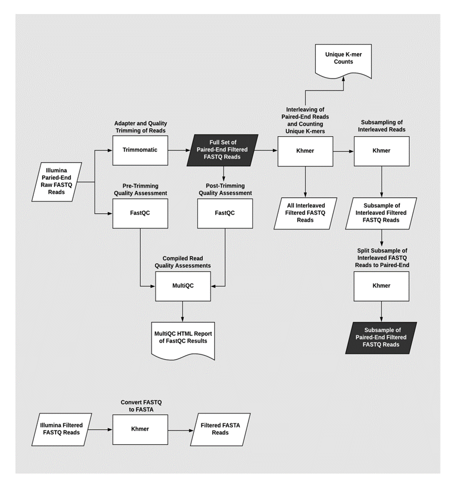

Read trimming workflow

## General statistics

```r
read_tsv(paste0(id, "_fastqc_multiqc_report_data/multiqc_general_stats.txt")) %>%
  set_names(~str_remove(., "FastQC_mqc-generalstats-")) %>%
  mutate_if(is.double, round, 2) %>%
  DT::datatable(caption="General QA statistics about samples in this run.")
```

|  | Sample | percent_fails | percent_duplicates | total_sequences | avg_sequence_length | percent_gc |
| --- | --- | --- | --- | --- | --- | --- |
| 1 | SRR606249_subset10_1_reads_1_reads | 0 | 3.44 | 5400000 | 101 | 50 |
| 2 | SRR606249_subset10_1_reads_2_reads | 0 | 3.49 | 5400000 | 101 | 49 |
| 3 | SRR606249_subset10_1_reads_trim2_1 | 0 | 3.33 | 5337063 | 99.93 | 50 |
| 4 | SRR606249_subset10_1_reads_trim2_2 | 0 | 3.29 | 5337063 | 99.89 | 49 |
| 5 | SRR606249_subset10_1_reads_trim30_1 | 0 | 2.85 | 5044284 | 93.68 | 49 |
| 6 | SRR606249_subset10_1_reads_trim30_2 | 0 | 2.97 | 5044284 | 92.41 | 49 |

```r
get_unique_kmers <- function(file) {
  read_lines(file) %>%
    grep("unique k-mers", ., value=TRUE) %>%
    str_extract("\\d+") %>%
    as.integer()
}
list.files(pattern="uniqueK\\d\\d\\.txt") %>%
  tibble(file=.) %>%
  mutate(sample=str_extract(file, ".+trim\\d+")) %>%
  mutate(K=str_extract(file, "K\\d+")) %>%
  mutate(number_unique_kmers=map_int(file, get_unique_kmers)) %>%
  select(-file) %>%
  mutate_if(is.integer, scales::comma) %>%
  DT::datatable(caption="Number of unique kmers in each sample in this run.")
```

|  | sample | K | number_unique_kmers |
| --- | --- | --- | --- |
| 1 | SRR606249_subset10_1_reads_trim2 | K21 | 203,749,322 |
| 2 | SRR606249_subset10_1_reads_trim2 | K31 | 201,383,388 |
| 3 | SRR606249_subset10_1_reads_trim2 | K51 | 186,396,385 |
| 4 | SRR606249_subset10_1_reads_trim30 | K21 | 170,724,835 |
| 5 | SRR606249_subset10_1_reads_trim30 | K31 | 165,019,600 |
| 6 | SRR606249_subset10_1_reads_trim30 | K51 | 148,673,196 |

## MultiQC Reports: FastQC

Click for links to comprehensive quality assessment reports:

```r
x <- list.files(pattern="fastqc_multiqc_report\\.html$")
glue::glue("- **[{x}]({x})**") %>%
  cat(sep="\n")
```

- **SRR606249_subset10_1_reads_fastqc_multiqc_report.html**

## Detailed FastQC statistics

```r
read_tsv(paste0(id, "_fastqc_multiqc_report_data/multiqc_fastqc.txt")) %>%
  DT::datatable(caption="Comprehensive information from FastQC (side-scroll to see more)", options = list(scrollX='600px'))
```

|  | Sample | adapter_content | Sequences flagged as poor quality | sequence_duplication_levels | total_deduplicated_percentage | overrepresented_sequences | per_sequence_quality_scores | sequence_length_distribution | per_sequence_gc_content | Total Sequences | Filename | per_base_sequence_content | File type | per_base_sequence_quality | %GC | Encoding | basic_statistics | Sequence length | per_base_n_content | avg_sequence_length |
| --- | --- | --- | --- | --- | --- | --- | --- | --- | --- | --- | --- | --- | --- | --- | --- | --- | --- | --- | --- | --- |
| 1 | SRR606249_subset10_1_reads_1_reads | pass | 0 | pass | 96.5594415838144 | pass | pass | pass | warn | 5400000 | SRR606249_subset10_1_reads_1_reads.fq.gz | warn | Conventional base calls | pass | 50 | Sanger / Illumina 1.9 | pass | 101.0 | pass | 101 |
| 2 | SRR606249_subset10_1_reads_2_reads | pass | 0 | pass | 96.5053901247476 | warn | pass | pass | warn | 5400000 | SRR606249_subset10_1_reads_2_reads.fq.gz | warn | Conventional base calls | pass | 49 | Sanger / Illumina 1.9 | pass | 101.0 | pass | 101 |
| 3 | SRR606249_subset10_1_reads_trim2_1 | pass | 0 | pass | 96.6716576082551 | pass | pass | warn | warn | 5337063 | SRR606249_subset10_1_reads_trim2_1.fq.gz | warn | Conventional base calls | pass | 50 | Sanger / Illumina 1.9 | pass | 25-101 | pass | 99.9261331560073 |
| 4 | SRR606249_subset10_1_reads_trim2_2 | pass | 0 | pass | 96.7083384268681 | pass | pass | warn | warn | 5337063 | SRR606249_subset10_1_reads_trim2_2.fq.gz | warn | Conventional base calls | pass | 49 | Sanger / Illumina 1.9 | pass | 25-101 | pass | 99.8949602056412 |
| 5 | SRR606249_subset10_1_reads_trim30_1 | pass | 0 | pass | 97.1496193250422 | pass | pass | warn | warn | 5044284 | SRR606249_subset10_1_reads_trim30_1.fq.gz | warn | Conventional base calls | pass | 49 | Sanger / Illumina 1.9 | pass | 25-101 | pass | 93.6794597607906 |
| 6 | SRR606249_subset10_1_reads_trim30_2 | pass | 0 | pass | 97.0260156021679 | pass | pass | warn | warn | 5044284 | SRR606249_subset10_1_reads_trim30_2.fq.gz | warn | Conventional base calls | pass | 49 | Sanger / Illumina 1.9 | pass | 25-101 | pass | 92.4113606608986 |

```r
read_tsv(paste0(id, "_fastqc_multiqc_report_data/multiqc_sources.txt")) %>%
  DT::datatable(caption="MultiQC Data Sources")
```

|  | Module | Section | Sample Name | Source |
| --- | --- | --- | --- | --- |
| 1 | FastQC | all_sections | SRR606249_subset10_1_reads_trim2_2 | /tmp/SRR606249_subset10_1_reads_trim2_2_fastqc.zip |
| 2 | FastQC | all_sections | SRR606249_subset10_1_reads_trim2_1 | /tmp/SRR606249_subset10_1_reads_trim2_1_fastqc.zip |
| 3 | FastQC | all_sections | SRR606249_subset10_1_reads_2_reads | //tmp/SRR606249_subset10_1_reads_2_reads_fastqc.zip |
| 4 | FastQC | all_sections | SRR606249_subset10_1_reads_1_reads | //tmp/SRR606249_subset10_1_reads_1_reads_fastqc.zip |
| 5 | FastQC | all_sections | SRR606249_subset10_1_reads_trim30_1 | /tmp/SRR606249_subset10_1_reads_trim30_1_fastqc.zip |
| 6 | FastQC | all_sections | SRR606249_subset10_1_reads_trim30_2 | /tmp/SRR606249_subset10_1_reads_trim30_2_fastqc.zip |

# Taxonomic Classification

## Procedure

This workflow will perform taxonomic classification with sourmash version 2.0.0a3 and kaiju version 1.6.1 on filtered Illumina paired-end reads, as well as visualizations of kaiju results with KronaTools version 2.7. It has been tested to run offline following the execution of the Read Filtering Workflow.

**More info: https://github.com/signaturescience/metagenomics/wiki/08.-Taxonomic-Classification**

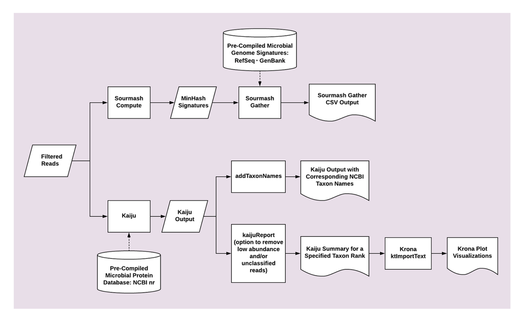

Taxonomic classification workflow

## Krona plots

### Links to existing HTML files

Click for links to krona diagrams:

```r
x <- list.files(pattern=".*krona.*html$")
glue::glue("- **[{x}]({x})**") %>%
  cat(sep="\n")
```

- **SRR606249_subset10_1_reads_trim2.kaiju_genus_krona.html**
- **SRR606249_subset10_1_reads_trim30.kaiju_genus_krona.html**

### Direct Krona embedding

```r
list.files(pattern="krona\\.html$") %>%
  paste0("\n", ., ":\n\n", '<iframe src="', ., '" width="1000" height="1000"></iframe>\n\n') %>%
  cat()
```

SRR606249_subset10_1_reads_trim2.kaiju_genus_krona.html:

[interactive chart not shown]

SRR606249_subset10_1_reads_trim30.kaiju_genus_krona.html:

[interactive chart not shown]

## Kaiju results

### Direct links to files

```r
x <- list.files(pattern="kaiju.+summary$")
glue::glue("- **[{x}]({x})**") %>%
  cat(sep="\n")
```

- **SRR606249_subset10_1_reads_trim2.kaiju_genus.summary**
- **SRR606249_subset10_1_reads_trim30.kaiju_genus.summary**

### Inline reports

For brevity, the inline reports shown here only display the top 50 results for each sample. Please click the *“Direct links to files”* button above to download and view the full results for each sample.

```r
# readLines(x[1]) %>%
#   cat(sep="\n")
for (i in x) {
  cat("\n", i, "\n\n")
  cat(readLines(i, n=52), sep="\n")
  cat("\n\n\n\n")
}
```

```
##
##  SRR606249_subset10_1_reads_trim2.kaiju_genus.summary
##
##         %        reads   genus
## -------------------------------------------
##  9.044113       482690   Rhodopirellula
##  7.396034       394731   Thermotoga
##  4.748960       253455   Sulfitobacter
##  4.190657       223658   Pyrobaculum
##  3.770108       201213   Gemmatimonas
##  3.622123       193315   Chlorobium
##  3.352949       178949   Pyrococcus
##  2.906467       155120   Acidobacterium
##  2.871898       153275   Nitrosomonas
##  2.508084       133858   Geobacter
##  2.455320       131042   Archaeoglobus
##  2.335442       124644   Sulfolobus
##  2.096303       111881   Bacteroides
##  2.036045       108665   Desulfovibrio
##  1.911182       102001   Caldicellulosiruptor
##  1.789261        95494   Salinispora
##  1.626868        86827   Treponema
##  1.617594        86332   Chloroflexus
##  1.456813        77751   Methanococcus
##  1.438600        76779   Nostoc
##  1.373527        73306   Herpetosiphon
##  1.358050        72480   Nanoarchaeum
##  1.346077        71841   Persephonella
##  1.346059        71840   Hydrogenobaculum
##  1.159983        61909   Sulfurihydrogenibium
##  1.067610        56979   Aciduliprofundum
##  1.061520        56654   Leptothrix
##  1.046699        55863   Thermus
##  1.039148        55460   Ruminiclostridium
##  0.982806        52453   Methanocaldococcus
##  0.979190        52260   Chlorobaculum
##  0.973607        51962   Pelodictyon
##  0.972801        51919   Shewanella
##  0.953258        50876   Proteiniclasticum
##  0.920300        49117   Methanopyrus
```

[output cut: 59 more lines]

```
##  0.890513        44920   Methanosarcina
##  0.842558        42501   Akkermansia
##  0.839188        42331   Wolinella
##  0.835817        42161   Dictyoglomus
##  0.832170        41977   Haloferax
##  0.705115        35568   Porphyromonas
##  0.605140        30525   Deinococcus
##  0.460779        23243   Ruegeria
##  0.456834        23044   Fusobacterium
##  0.423529        21364   Paraburkholderia
##  0.350397        17675   Thermoanaerobacter
##  0.287058        14480   Ignicoccus
##  0.246774        12448   Bordetella
##  0.234364        11822   Zymomonas
##  0.143588         7243   Enterococcus
```

## Sourmash Gather Detailed results

### Direct links to spreadsheets

```r
x <- list.files(pattern="gather_output.csv$")
glue::glue("- **[{x}]({x})**") %>%
  cat(sep="\n")
```

- **SRR606249_subset10_1_reads_trim2_k21.gather_output.csv**
- **SRR606249_subset10_1_reads_trim2_k31.gather_output.csv**
- **SRR606249_subset10_1_reads_trim2_k51.gather_output.csv**
- **SRR606249_subset10_1_reads_trim30_k21.gather_output.csv**
- **SRR606249_subset10_1_reads_trim30_k31.gather_output.csv**
- **SRR606249_subset10_1_reads_trim30_k51.gather_output.csv**

### Trim2 k=21

```r
read_csv(paste0(id, "_trim2_k21.gather_output.csv")) %>%
  mutate_if(is.double, round, 2) %>%
  DT::datatable(caption="Sourmash Gather results for k=21 (side-scroll to see more)", options = list(scrollX='600px'))
```

|  | intersect_bp | f_orig_query | f_match | f_unique_to_query | f_unique_weighted | average_abund | name | filename | md5 |
| --- | --- | --- | --- | --- | --- | --- | --- | --- | --- |
| 1 | 6600000 | 0.03 | 1 | 0.03 | 0.09 | 11.3 | BX119912.1 Rhodopirellula baltica SH 1 complete genome | data/refseq-k21.sbt.json | 7f160cdfaaa1bd3cb9345dde78061521 |
| 2 | 5730000 | 0.03 | 0.83 | 0.03 | 0.02 | 3.12 | BA000019.2 Nostoc sp. PCC 7120 DNA, complete genome | data/refseq-k21.sbt.json | 49dcc05178ac72326de9646578f376e3 |
| 3 | 5400000 | 0.03 | 0.8 | 0.03 | 0.01 | 2.29 | CP000875.1 Herpetosiphon aurantiacus DSM 785, complete genome | data/refseq-k21.sbt.json | 83bd36beaea8594fb28d3e4e44fe563f |
| 4 | 5150000 | 0.03 | 0.84 | 0.03 | 0.01 | 2.39 | AE015928.1 Bacteroides thetaiotaomicron VPI-5482, complete genome | data/refseq-k21.sbt.json | 12cd55e54f72933ac8eb37ca369663bd |
| 5 | 5000000 | 0.02 | 1 | 0.02 | 0.04 | 6.95 | AP009153.1 Gemmatimonas aurantiaca T-27 DNA, complete genome | data/refseq-k21.sbt.json | c35c32df9d43c14ed9f81e35f2331e06 |
| 6 | 4730000 | 0.02 | 0.5 | 0.02 | 0.01 | 1.65 | CP000270.1 Burkholderia xenovorans LB400 chromosome 1, complete sequence | data/refseq-k21.sbt.json | c7a74b6e204c56a29a67582e3003c4d5 |
| 7 | 4360000 | 0.02 | 0.91 | 0.02 | 0.02 | 3.1 | CP001364.1 Chloroflexus sp. Y-400-fl, complete genome | data/refseq-k21.sbt.json | c63bdc8ad8823143c2bb0fc05536cdd9 |
| 8 | 4080000 | 0.02 | 0.99 | 0.02 | 0.03 | 6.4 | CP001472.1 Acidobacterium capsulatum ATCC 51196, complete genome | data/refseq-k21.sbt.json | 4eef1714ac63252d3b183be5fa37ea57 |
| 9 | 3970000 | 0.02 | 0.73 | 0.02 | 0.01 | 2.49 | CP000850.1 Salinispora arenicola CNS-205, complete genome | data/refseq-k21.sbt.json | 181a22864d94d8556d60def06b382102 |
| 10 | 3940000 | 0.02 | 1 | 0.02 | 0.05 | 10.29 | CH959317.1 Sulfitobacter sp. NAS-14.1 scf_1099451320472 genomic scaffold, whole genome shotgun sequence | data/refseq-k21.sbt.json | 6ccfc2298d432314844cae985cabcff6 |

[output cut: 64 more lines]

### Trim2 k=31

```r
read_csv(paste0(id,"_trim2_k31.gather_output.csv")) %>%
  mutate_if(is.double, round, 2) %>%
  DT::datatable(caption="Sourmash Gather results for k=31 (side-scroll to see more)", options = list(scrollX='600px'))
```

|  | intersect_bp | f_orig_query | f_match | f_unique_to_query | f_unique_weighted | average_abund | name | filename | md5 |
| --- | --- | --- | --- | --- | --- | --- | --- | --- | --- |
| 1 | 6830000 | 0.03 | 1 | 0.03 | 0.09 | 9.61 | BX119912.1 Rhodopirellula baltica SH 1 complete genome | data/refseq-k31.sbt.json | fe2f7e3e143e72582f902ff258901d47 |
| 2 | 6540000 | 0.03 | 0.83 | 0.03 | 0.03 | 2.91 | BA000019.2 Nostoc sp. PCC 7120 DNA, complete genome | data/refseq-k31.sbt.json | b707f3cdca627cd3c985ada91454874e |
| 3 | 5060000 | 0.02 | 0.8 | 0.02 | 0.01 | 2.09 | CP000875.1 Herpetosiphon aurantiacus DSM 785, complete genome | data/refseq-k31.sbt.json | e04a17715259ffe539c22d2f480a2484 |
| 4 | 4770000 | 0.02 | 0.77 | 0.02 | 0.01 | 2.13 | AE015928.1 Bacteroides thetaiotaomicron VPI-5482, complete genome | data/refseq-k31.sbt.json | 8affae43de8758c8d77c302cacc884ab |
| 5 | 4670000 | 0.02 | 0.89 | 0.02 | 0.02 | 2.76 | CP000909.1 Chloroflexus aurantiacus J-10-fl, complete genome | data/refseq-k31.sbt.json | 6cf63ffd3b4cdd74285f8c2ea5c04d78 |
| 6 | 4460000 | 0.02 | 0.99 | 0.02 | 0.04 | 6.16 | AP009153.1 Gemmatimonas aurantiaca T-27 DNA, complete genome | data/refseq-k31.sbt.json | ea5b483d89c2834cba889470ee54bc06 |
| 7 | 4250000 | 0.02 | 0.99 | 0.02 | 0.03 | 5.58 | CP001472.1 Acidobacterium capsulatum ATCC 51196, complete genome | data/refseq-k31.sbt.json | 53ae51540690b8114e8c9b1de15ac31f |
| 8 | 4060000 | 0.02 | 0.44 | 0.02 | 0.01 | 1.56 | CP000270.1 Burkholderia xenovorans LB400 chromosome 1, complete sequence | data/refseq-k31.sbt.json | 00ba560c11b5aed2491ac8a484d4e210 |
| 9 | 4050000 | 0.02 | 0.71 | 0.02 | 0.01 | 2.19 | CP000850.1 Salinispora arenicola CNS-205, complete genome | data/refseq-k31.sbt.json | 9cd58999b3384a98ae6e1c6d42918dff |
| 10 | 3890000 | 0.02 | 0.74 | 0.02 | 0.01 | 1.85 | AE010299.1 Methanosarcina acetivorans str. C2A, complete genome | data/refseq-k31.sbt.json | 5a9fc0ee959336a305ee239f9b66b7b9 |

[output cut: 64 more lines]

### Trim2 k=51

```r
read_csv(paste0(id,"_trim2_k51.gather_output.csv")) %>%
  mutate_if(is.double, round, 2) %>%
  DT::datatable(caption="Sourmash Gather results for k=51 (side-scroll to see more)", options = list(scrollX='600px'))
```

|  | intersect_bp | f_orig_query | f_match | f_unique_to_query | f_unique_weighted | average_abund | name | filename | md5 |
| --- | --- | --- | --- | --- | --- | --- | --- | --- | --- |
| 1 | 7420000 | 0.04 | 0.99 | 0.04 | 0.09 | 6.69 | BX119912.1 Rhodopirellula baltica SH 1 complete genome | data/refseq-k51.sbt.json | 0158c8fed04b7805bd8b6c9b1deb0457 |
| 2 | 5270000 | 0.03 | 0.72 | 0.03 | 0.02 | 2.46 | BA000019.2 Nostoc sp. PCC 7120 DNA, complete genome | data/refseq-k51.sbt.json | 65dee47a2f5d0719c93a0f14398574d4 |
| 3 | 4530000 | 0.02 | 0.64 | 0.02 | 0.02 | 1.83 | CP000875.1 Herpetosiphon aurantiacus DSM 785, complete genome | data/refseq-k51.sbt.json | d5fb91a1945683fed1128ce3a59570eb |
| 4 | 4350000 | 0.02 | 0.78 | 0.02 | 0.02 | 2.24 | CP000909.1 Chloroflexus aurantiacus J-10-fl, complete genome | data/refseq-k51.sbt.json | 8f4d200ad2557c0da2a57913c21c0354 |
| 5 | 4240000 | 0.02 | 0.96 | 0.02 | 0.03 | 4.18 | AP009153.1 Gemmatimonas aurantiaca T-27 DNA, complete genome | data/refseq-k51.sbt.json | d39f70f284ac206dee2ee61b8a680a8b |
| 6 | 4060000 | 0.02 | 0.96 | 0.02 | 0.03 | 4.19 | CP001472.1 Acidobacterium capsulatum ATCC 51196, complete genome | data/refseq-k51.sbt.json | 25e2ad37d2f90d5d6ed8ec0521b7a059 |
| 7 | 4000000 | 0.02 | 0.66 | 0.02 | 0.01 | 1.87 | AE015928.1 Bacteroides thetaiotaomicron VPI-5482, complete genome | data/refseq-k51.sbt.json | 0b4c0b9a93b1998725462732d6b6a016 |
| 8 | 3840000 | 0.02 | 0.96 | 0.02 | 0.04 | 5.6 | CH959317.1 Sulfitobacter sp. NAS-14.1 scf_1099451320472 genomic scaffold, whole genome shotgun sequence | data/refseq-k51.sbt.json | 4191f9193be96dbebba5ebaabc75dcf1 |
| 9 | 3770000 | 0.02 | 0.96 | 0.02 | 0.03 | 3.71 | AE017180.2 Geobacter sulfurreducens PCA, complete genome | data/refseq-k51.sbt.json | d1c43766838dfffdefe2cf17d0742d12 |
| 10 | 3510000 | 0.02 | 0.61 | 0.02 | 0.01 | 1.77 | CP000850.1 Salinispora arenicola CNS-205, complete genome | data/refseq-k51.sbt.json | 9429201e056e9e0f78ac9d9594289e82 |

[output cut: 65 more lines]

### Trim30 k=21

```r
read_csv(paste0(id,"_trim30_k21.gather_output.csv")) %>%
  mutate_if(is.double, round, 2) %>%
  DT::datatable(caption="Sourmash Gather results for k=21 (side-scroll to see more)", options = list(scrollX='600px'))
```

|  | intersect_bp | f_orig_query | f_match | f_unique_to_query | f_unique_weighted | average_abund | name | filename | md5 |
| --- | --- | --- | --- | --- | --- | --- | --- | --- | --- |
| 1 | 6600000 | 0.04 | 1 | 0.04 | 0.09 | 9.97 | BX119912.1 Rhodopirellula baltica SH 1 complete genome | data/refseq-k21.sbt.json | 7f160cdfaaa1bd3cb9345dde78061521 |
| 2 | 5530000 | 0.03 | 0.8 | 0.03 | 0.02 | 2.98 | BA000019.2 Nostoc sp. PCC 7120 DNA, complete genome | data/refseq-k21.sbt.json | 49dcc05178ac72326de9646578f376e3 |
| 3 | 5210000 | 0.03 | 0.77 | 0.03 | 0.02 | 2.2 | CP000875.1 Herpetosiphon aurantiacus DSM 785, complete genome | data/refseq-k21.sbt.json | 83bd36beaea8594fb28d3e4e44fe563f |
| 4 | 5000000 | 0.03 | 0.82 | 0.03 | 0.02 | 2.27 | AE015928.1 Bacteroides thetaiotaomicron VPI-5482, complete genome | data/refseq-k21.sbt.json | 12cd55e54f72933ac8eb37ca369663bd |
| 5 | 4930000 | 0.03 | 0.98 | 0.03 | 0.04 | 5.79 | AP009153.1 Gemmatimonas aurantiaca T-27 DNA, complete genome | data/refseq-k21.sbt.json | c35c32df9d43c14ed9f81e35f2331e06 |
| 6 | 4170000 | 0.02 | 0.87 | 0.02 | 0.02 | 2.84 | CP001364.1 Chloroflexus sp. Y-400-fl, complete genome | data/refseq-k21.sbt.json | c63bdc8ad8823143c2bb0fc05536cdd9 |
| 7 | 4140000 | 0.02 | 0.44 | 0.02 | 0.01 | 1.56 | CP000270.1 Burkholderia xenovorans LB400 chromosome 1, complete sequence | data/refseq-k21.sbt.json | c7a74b6e204c56a29a67582e3003c4d5 |
| 8 | 4050000 | 0.02 | 0.99 | 0.02 | 0.03 | 5.6 | CP001472.1 Acidobacterium capsulatum ATCC 51196, complete genome | data/refseq-k21.sbt.json | 4eef1714ac63252d3b183be5fa37ea57 |
| 9 | 3940000 | 0.02 | 1 | 0.02 | 0.05 | 8.77 | CH959317.1 Sulfitobacter sp. NAS-14.1 scf_1099451320472 genomic scaffold, whole genome shotgun sequence | data/refseq-k21.sbt.json | 6ccfc2298d432314844cae985cabcff6 |
| 10 | 3780000 | 0.02 | 0.97 | 0.02 | 0.03 | 5.21 | AE017180.2 Geobacter sulfurreducens PCA, complete genome | data/refseq-k21.sbt.json | 4176760dfc22f8fbbba7f7c3326a3c22 |

[output cut: 64 more lines]

### Trim30 k=31

```r
read_csv(paste0(id,"_trim30_k31.gather_output.csv")) %>%
  mutate_if(is.double, round, 2) %>%
  DT::datatable(caption="Sourmash Gather results for k=31 (side-scroll to see more)", options = list(scrollX='600px'))
```

|  | intersect_bp | f_orig_query | f_match | f_unique_to_query | f_unique_weighted | average_abund | name | filename | md5 |
| --- | --- | --- | --- | --- | --- | --- | --- | --- | --- |
| 1 | 6820000 | 0.04 | 1 | 0.04 | 0.09 | 8.37 | BX119912.1 Rhodopirellula baltica SH 1 complete genome | data/refseq-k31.sbt.json | fe2f7e3e143e72582f902ff258901d47 |
| 2 | 6330000 | 0.04 | 0.8 | 0.04 | 0.03 | 2.82 | BA000019.2 Nostoc sp. PCC 7120 DNA, complete genome | data/refseq-k31.sbt.json | b707f3cdca627cd3c985ada91454874e |
| 3 | 4780000 | 0.03 | 0.76 | 0.03 | 0.01 | 1.97 | CP000875.1 Herpetosiphon aurantiacus DSM 785, complete genome | data/refseq-k31.sbt.json | e04a17715259ffe539c22d2f480a2484 |
| 4 | 4600000 | 0.03 | 0.75 | 0.03 | 0.01 | 2.05 | AE015928.1 Bacteroides thetaiotaomicron VPI-5482, complete genome | data/refseq-k31.sbt.json | 8affae43de8758c8d77c302cacc884ab |
| 5 | 4410000 | 0.03 | 0.84 | 0.03 | 0.02 | 2.5 | CP000909.1 Chloroflexus aurantiacus J-10-fl, complete genome | data/refseq-k31.sbt.json | 6cf63ffd3b4cdd74285f8c2ea5c04d78 |
| 6 | 4370000 | 0.03 | 0.97 | 0.03 | 0.03 | 5.06 | AP009153.1 Gemmatimonas aurantiaca T-27 DNA, complete genome | data/refseq-k31.sbt.json | ea5b483d89c2834cba889470ee54bc06 |
| 7 | 4180000 | 0.02 | 0.97 | 0.02 | 0.03 | 4.81 | CP001472.1 Acidobacterium capsulatum ATCC 51196, complete genome | data/refseq-k31.sbt.json | 53ae51540690b8114e8c9b1de15ac31f |
| 8 | 3800000 | 0.02 | 0.97 | 0.02 | 0.04 | 7.44 | CH959317.1 Sulfitobacter sp. NAS-14.1 scf_1099451320472 genomic scaffold, whole genome shotgun sequence | data/refseq-k31.sbt.json | 5d89b30ca0135902efc54d4dfef06c07 |
| 9 | 3750000 | 0.02 | 0.71 | 0.02 | 0.01 | 1.79 | AE010299.1 Methanosarcina acetivorans str. C2A, complete genome | data/refseq-k31.sbt.json | 5a9fc0ee959336a305ee239f9b66b7b9 |
| 10 | 3670000 | 0.02 | 0.7 | 0.02 | 0.01 | 1.76 | CP000139.1 Bacteroides vulgatus ATCC 8482, complete genome | data/refseq-k31.sbt.json | c2a9fe2dfaa14f88998b7d1dabc05f46 |

[output cut: 64 more lines]

### Trim30 k=51

```r
read_csv(paste0(id,"_trim30_k51.gather_output.csv")) %>%
  mutate_if(is.double, round, 2) %>%
  DT::datatable(caption="Sourmash Gather results for k=51 (side-scroll to see more)", options = list(scrollX='600px'))
```

|  | intersect_bp | f_orig_query | f_match | f_unique_to_query | f_unique_weighted | average_abund | name | filename | md5 |
| --- | --- | --- | --- | --- | --- | --- | --- | --- | --- |
| 1 | 7340000 | 0.05 | 0.98 | 0.05 | 0.09 | 5.72 | BX119912.1 Rhodopirellula baltica SH 1 complete genome | data/refseq-k51.sbt.json | 0158c8fed04b7805bd8b6c9b1deb0457 |
| 2 | 5050000 | 0.03 | 0.69 | 0.03 | 0.03 | 2.32 | BA000019.2 Nostoc sp. PCC 7120 DNA, complete genome | data/refseq-k51.sbt.json | 65dee47a2f5d0719c93a0f14398574d4 |
| 3 | 4230000 | 0.03 | 0.6 | 0.03 | 0.02 | 1.72 | CP000875.1 Herpetosiphon aurantiacus DSM 785, complete genome | data/refseq-k51.sbt.json | d5fb91a1945683fed1128ce3a59570eb |
| 4 | 3970000 | 0.03 | 0.9 | 0.03 | 0.03 | 3.36 | AP009153.1 Gemmatimonas aurantiaca T-27 DNA, complete genome | data/refseq-k51.sbt.json | d39f70f284ac206dee2ee61b8a680a8b |
| 5 | 3900000 | 0.03 | 0.92 | 0.03 | 0.03 | 3.56 | CP001472.1 Acidobacterium capsulatum ATCC 51196, complete genome | data/refseq-k51.sbt.json | 25e2ad37d2f90d5d6ed8ec0521b7a059 |
| 6 | 3900000 | 0.03 | 0.7 | 0.03 | 0.02 | 2.04 | CP000909.1 Chloroflexus aurantiacus J-10-fl, complete genome | data/refseq-k51.sbt.json | 8f4d200ad2557c0da2a57913c21c0354 |
| 7 | 3820000 | 0.03 | 0.63 | 0.03 | 0.02 | 1.8 | AE015928.1 Bacteroides thetaiotaomicron VPI-5482, complete genome | data/refseq-k51.sbt.json | 0b4c0b9a93b1998725462732d6b6a016 |
| 8 | 3730000 | 0.02 | 0.93 | 0.02 | 0.04 | 4.57 | CH959317.1 Sulfitobacter sp. NAS-14.1 scf_1099451320472 genomic scaffold, whole genome shotgun sequence | data/refseq-k51.sbt.json | 4191f9193be96dbebba5ebaabc75dcf1 |
| 9 | 3520000 | 0.02 | 0.89 | 0.02 | 0.02 | 3.12 | AE017180.2 Geobacter sulfurreducens PCA, complete genome | data/refseq-k51.sbt.json | d1c43766838dfffdefe2cf17d0742d12 |
| 10 | 3120000 | 0.02 | 0.58 | 0.02 | 0.01 | 1.5 | AE010299.1 Methanosarcina acetivorans str. C2A, complete genome | data/refseq-k51.sbt.json | 130c04e39dcd6f64ce342349a618f397 |

[output cut: 65 more lines]

# Assembly

## Procedure

The tools within this workflow perform metagenome assemblies with the de novo assemblers metaSPAdes in SPAdes version 3.11.1, as well as MEGAHIT version 1.1.2, on trimmed Illumina paired-end reads. QUAST version 4.5 is used to evaluate the assemblies, and MultiQC version 1.4 provides aggregated visualizations for the QUAST reports of each assembler. This workflow has been tested to run offline in an air-gapped system following the execution of the Read Filtering Workflow.

**More info: https://github.com/signaturescience/metagenomics/wiki/06.-Assembly**

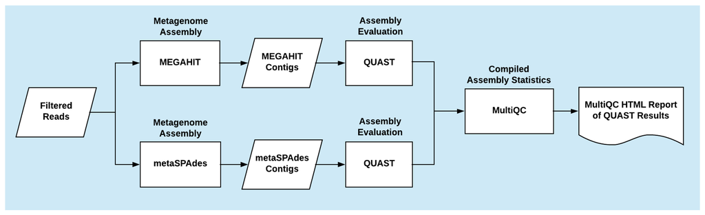

Assembly workflow

## General statistics

### MEGAHIT

```r
read_tsv(paste0(id, ".megahit_multiqc_report_data/multiqc_general_stats.txt")) %>%
  set_names(~str_remove(., "QUAST_mqc-generalstats-")) %>%
  select(Sample, Total_length, N50) %>%
  DT::datatable(caption="General assembly statistics about samples in this run from MEGAHIT.")
```

|  | Sample | Total_length | N50 |
| --- | --- | --- | --- |
| 1 | SRR606249_subset10_1_reads_trim2.megahit.contigs | 109630505 | 2886 |
| 2 | SRR606249_subset10_1_reads_trim30.megahit.contigs | 97210488 | 2431 |

### MetaSPADES

```r
read_tsv(paste0(id, ".metaspades_multiqc_report_data/multiqc_general_stats.txt")) %>%
  set_names(~str_remove(., "QUAST_mqc-generalstats-")) %>%
  select(Sample, Total_length, N50) %>%
  DT::datatable(caption="General assembly statistics about samples in this run from MetaSPADES.")
```

|  | Sample | Total_length | N50 |
| --- | --- | --- | --- |
| 1 | SRR606249_subset10_1_reads_trim2.metaspades.contigs | 114622322 | 2644 |
| 2 | SRR606249_subset10_1_reads_trim30.metaspades.contigs | 103089334 | 2324 |

## QUAST

### MultiQC reports

Click for links to comprehensive quality assessment reports:

```r
x <- list.files(pattern="(megahit|metaspades)_multiqc_report\\.html$")
glue::glue("- **[{x}]({x})**") %>%
  cat(sep="\n")
```

- **SRR606249_subset10_1_reads.megahit_multiqc_report.html**
- **SRR606249_subset10_1_reads.metaspades_multiqc_report.html**

### Individual QUAST reports

Individual QUAST reports:

```r
x <- list.files(pattern="^report\\.html$", recursive=TRUE)
glue::glue("- **[{x}]({x})**") %>%
  cat(sep="\n")
```

- **SRR606249_subset10_1_reads_trim2.megahit_quast/report.html**
- **SRR606249_subset10_1_reads_trim2.metaspades_quast/report.html**
- **SRR606249_subset10_1_reads_trim30.megahit_quast/report.html**
- **SRR606249_subset10_1_reads_trim30.metaspades_quast/report.html**

## Detailed results

### MEGAHIT

```r
read_tsv(paste0(id, ".megahit_multiqc_report_data/multiqc_quast.txt")) %>%
  DT::datatable(caption="Comprehensive information from QUAST (side-scroll to see more)", options = list(scrollX='600px'))
```

|  | Sample | # contigs (>= 1000 bp) | # contigs (>= 0 bp) | L50 | # contigs (>= 50000 bp) | GC (%) | # contigs (>= 10000 bp) | Total length (>= 25000 bp) | # contigs | Total length (>= 10000 bp) | N75 | # N's per 100 kbp | Total length (>= 0 bp) | # contigs (>= 25000 bp) | Largest contig | Total length (>= 5000 bp) | N50 | Total length (>= 1000 bp) | Total length (>= 50000 bp) | # contigs (>= 5000 bp) | Total length | L75 |
| --- | --- | --- | --- | --- | --- | --- | --- | --- | --- | --- | --- | --- | --- | --- | --- | --- | --- | --- | --- | --- | --- | --- |
| 1 | SRR606249_subset10_1_reads_trim2.megahit.contigs | 24966 | 108677 | 6146 | 99 | 49.65 | 1302 | 16209948 | 61812 | 30724332 | 1062 | 0 | 127627156 | 323 | 264437 | 43857446 | 2886 | 84241041 | 8530599 | 3202 | 109630505 | 23007 |
| 2 | SRR606249_subset10_1_reads_trim30.megahit.contigs | 23558 | 106560 | 7055 | 56 | 48.8 | 1033 | 10790234 | 58995 | 22432510 | 998 | 0 | 115452021 | 251 | 212072 | 34167638 | 2431 | 72867242 | 4193339 | 2751 | 97210488 | 23599 |

### MetaSPADES

```r
read_tsv(paste0(id, ".metaspades_multiqc_report_data/multiqc_quast.txt")) %>%
  DT::datatable(caption="Comprehensive information from QUAST (side-scroll to see more)", options = list(scrollX='600px'))
```

|  | Sample | Total length | N50 | L50 | Total length (>= 0 bp) | # contigs (>= 50000 bp) | GC (%) | # contigs (>= 10000 bp) | Total length (>= 5000 bp) | Total length (>= 50000 bp) | Total length (>= 1000 bp) | # N's per 100 kbp | # contigs (>= 0 bp) | Total length (>= 10000 bp) | Total length (>= 25000 bp) | # contigs (>= 1000 bp) | Largest contig | L75 | N75 | # contigs | # contigs (>= 25000 bp) | # contigs (>= 5000 bp) |
| --- | --- | --- | --- | --- | --- | --- | --- | --- | --- | --- | --- | --- | --- | --- | --- | --- | --- | --- | --- | --- | --- | --- |
| 1 | SRR606249_subset10_1_reads_trim2.metaspades.contigs | 114622322 | 2644 | 6829 | 149130139 | 117 | 49.62 | 1276 | 43999551 | 10040951 | 86531655 | 0 | 176202 | 31598052 | 17715767 | 26247 | 221137 | 25686 | 1014 | 67099 | 340 | 3072 |
| 2 | SRR606249_subset10_1_reads_trim30.metaspades.contigs | 103089334 | 2324 | 7609 | 137858025 | 72 | 48.77 | 1049 | 35581121 | 5529178 | 76295642 | 0 | 174419 | 24077498 | 12489985 | 24777 | 220860 | 25814 | 972 | 63813 | 272 | 2735 |

# Comparison

## Procedure

In this workflow, sourmash version 2.0.0a3 performs multi-sample metagenome comparisons. This is done by first generating MinHash signatures on the filtered reads (i.e., the Read Filtering Workflow output) or the assembled contigs (i.e., the Assembly Workflow output) with sourmash compute. The sourmash compare functionality then compares signatures from multiple datasets to each other and outputs their pairwise comparisons as Jaccard indexes in a final *.csv file. Currently, this workflow is designed to compare MinHash signatures of different quality trimmed values and assemblers for the same sample and output results in csv files and heatmap visualizations. Different samples can also be compared to each other, although confounding factors like sequencing depth can obscure the direct comparison of k-mer content in different samples.

**More info: https://github.com/signaturescience/metagenomics/wiki/07.-Comparison**

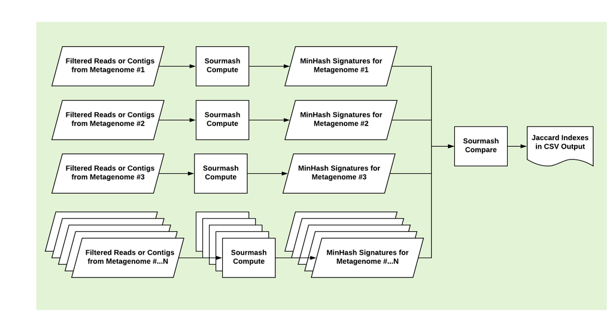

Comparison workflow

## CSVs

```r
x <- list.files(pattern="read_assembly_comparison", recursive=FALSE)
glue::glue("- **[{x}]({x})**") %>%
  cat(sep="\n")
```

- **SRR606249_subset10_1_readsandSRR606249_subset10_1_reads_read_assembly_comparison.k21.csv**
- **SRR606249_subset10_1_readsandSRR606249_subset10_1_reads_read_assembly_comparison.k21.png**
- **SRR606249_subset10_1_readsandSRR606249_subset10_1_reads_read_assembly_comparison.k31.csv**
- **SRR606249_subset10_1_readsandSRR606249_subset10_1_reads_read_assembly_comparison.k31.png**
- **SRR606249_subset10_1_readsandSRR606249_subset10_1_reads_read_assembly_comparison.k51.csv**
- **SRR606249_subset10_1_readsandSRR606249_subset10_1_reads_read_assembly_comparison.k51.png**

## PNGs

### Direct links to images

```r
x <- list.files(pattern="read_assembly_comparison.+\\.png$", recursive=TRUE)
bx <- basename(x)
glue::glue("- **[{bx}]({x})**") %>%
  cat(sep="\n")
```

- **SRR606249_subset10_1_readsandSRR606249_subset10_1_reads_read_assembly_comparison.k21.png**
- **SRR606249_subset10_1_readsandSRR606249_subset10_1_reads_read_assembly_comparison.k31.png**
- **SRR606249_subset10_1_readsandSRR606249_subset10_1_reads_read_assembly_comparison.k51.png**

### Inline graphics (in the same order as above)

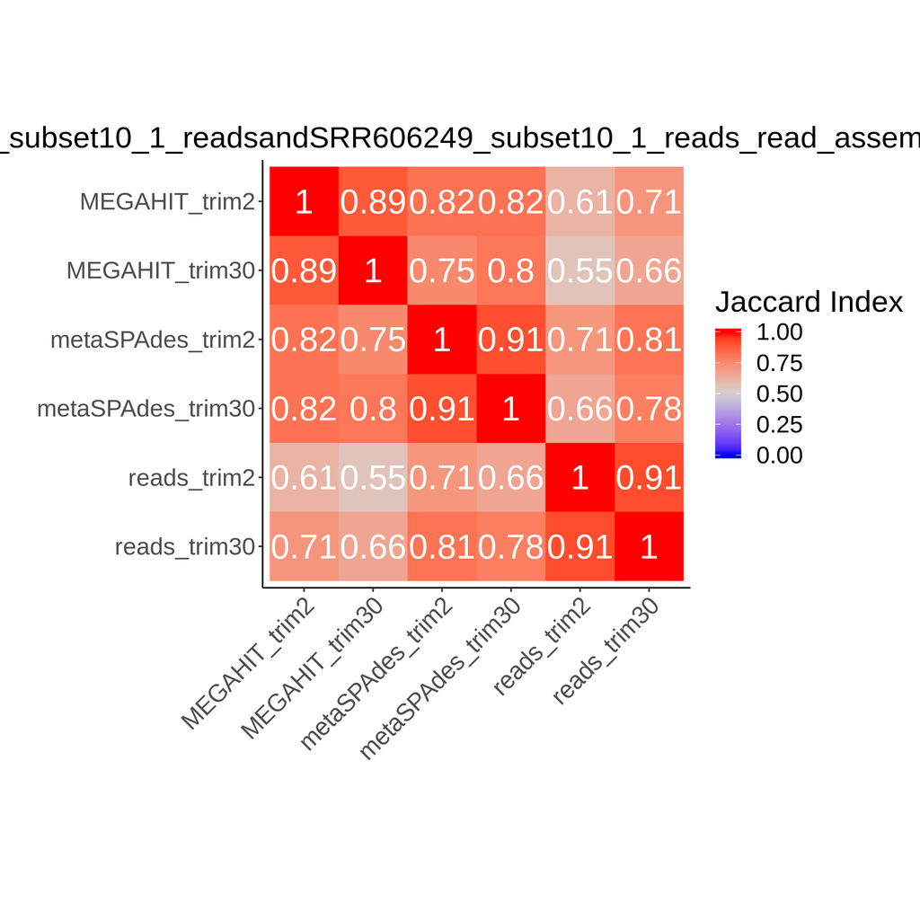

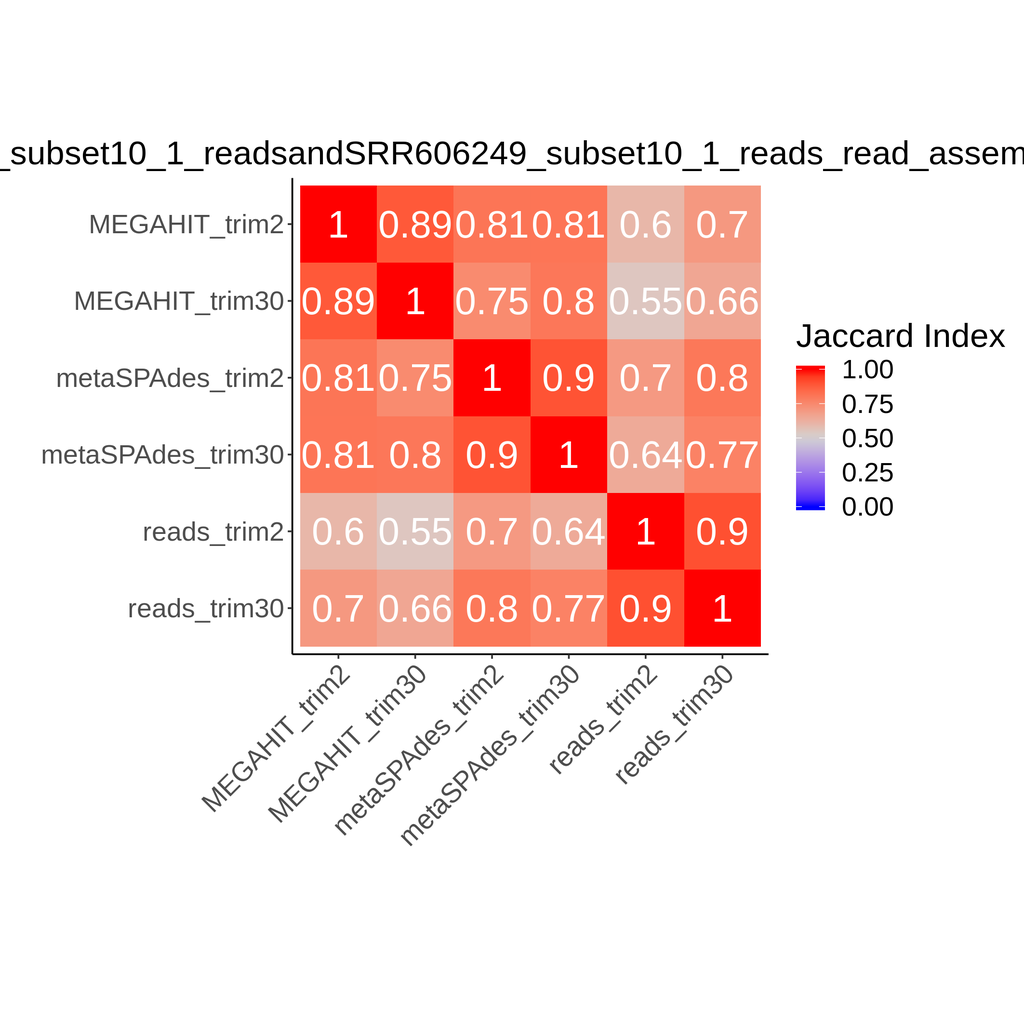

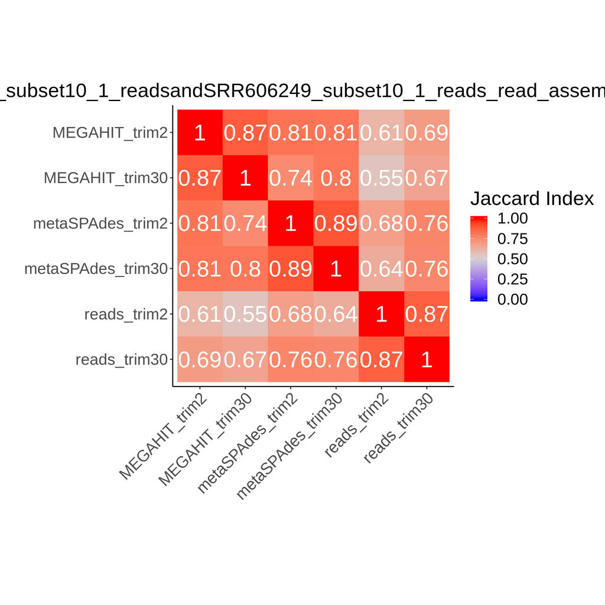

```r
knitr::include_graphics(x)
```

# Functional Inference

## Procedure

This workflow will perform functional inference (i.e., gene and plasmid detection) on filtered Illumina paired-end reads with SRST2 version 0.2.0, or on assembled contigs with prokka version 1.13.3 and ABRicate version 0.5. It has been tested to run offline after the execution of the Read Filtering Workflow and/or Assembly Workflow. Default prokka databases are used within the functional inference workflow, but users have the option of selecting from various pre-compiled databases for SRST2 and ABRicate.

**More info: https://github.com/signaturescience/metagenomics/wiki/09.-Functional-Inference**

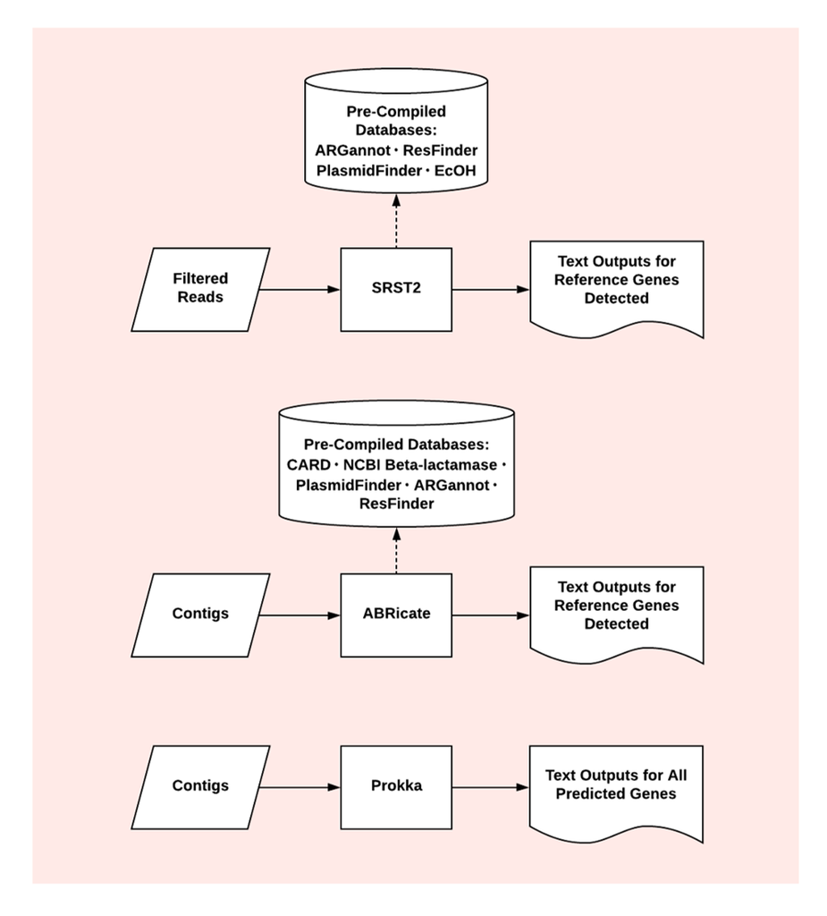

Functional inference workflow

## Prokka

Click below to access prokka results:

```r
x <- list.dirs() %>%
  grep(pattern = "prokka_annotation", x=., value=TRUE) %>%
  list.files(path=., pattern="\\.tsv", full.names = TRUE)
bx <- basename(x)
glue::glue("- **[{bx}]({x})**") %>%
  cat(sep="\n")
```

- **SRR606249_subset10_1_reads_trim2_megahit.tsv**
- **SRR606249_subset10_1_reads_trim2_metaspades.tsv**
- **SRR606249_subset10_1_reads_trim30_megahit.tsv**
- **SRR606249_subset10_1_reads_trim30_metaspades.tsv**

## Antibiotic resistance

### Abricate (contigs)

```r
x <- list.files(pattern="card\\.csv$")
glue::glue("- **[{x}]({x})**") %>%
  cat(sep="\n")
```

- **SRR606249_subset10_1_reads_trim2_megahit.abricate_card.csv**
- **SRR606249_subset10_1_reads_trim2_metaspades.abricate_card.csv**
- **SRR606249_subset10_1_reads_trim30_megahit.abricate_card.csv**
- **SRR606249_subset10_1_reads_trim30_metaspades.abricate_card.csv**

### SRST2 (reads)

```r
x <- list.files(pattern="srst2.*results\\.txt$")
glue::glue("- **[{x}]({x})**") %>%
  cat(sep="\n")
```

- **SRR606249_subset10_1_reads_trim2_ARGannot.r3.fasta.srst2__fullgenes__ARGannot.r3__results.txt**
- **SRR606249_subset10_1_reads_trim2_ARGannot.r3.fasta.srst2__genes__ARGannot.r3__results.txt**
- **SRR606249_subset10_1_reads_trim2_ResFinder.fasta.srst2__fullgenes__ResFinder__results.txt**
- **SRR606249_subset10_1_reads_trim2_ResFinder.fasta.srst2__genes__ResFinder__results.txt**
- **SRR606249_subset10_1_reads_trim30_ARGannot.r3.fasta.srst2__fullgenes__ARGannot.r3__results.txt**
- **SRR606249_subset10_1_reads_trim30_ARGannot.r3.fasta.srst2__genes__ARGannot.r3__results.txt**
- **SRR606249_subset10_1_reads_trim30_ResFinder.fasta.srst2__fullgenes__ResFinder__results.txt**
- **SRR606249_subset10_1_reads_trim30_ResFinder.fasta.srst2__genes__ResFinder__results.txt**